# Exploration of the Red Wine Quality Dataset by Pranesh Ramachandra Murthy

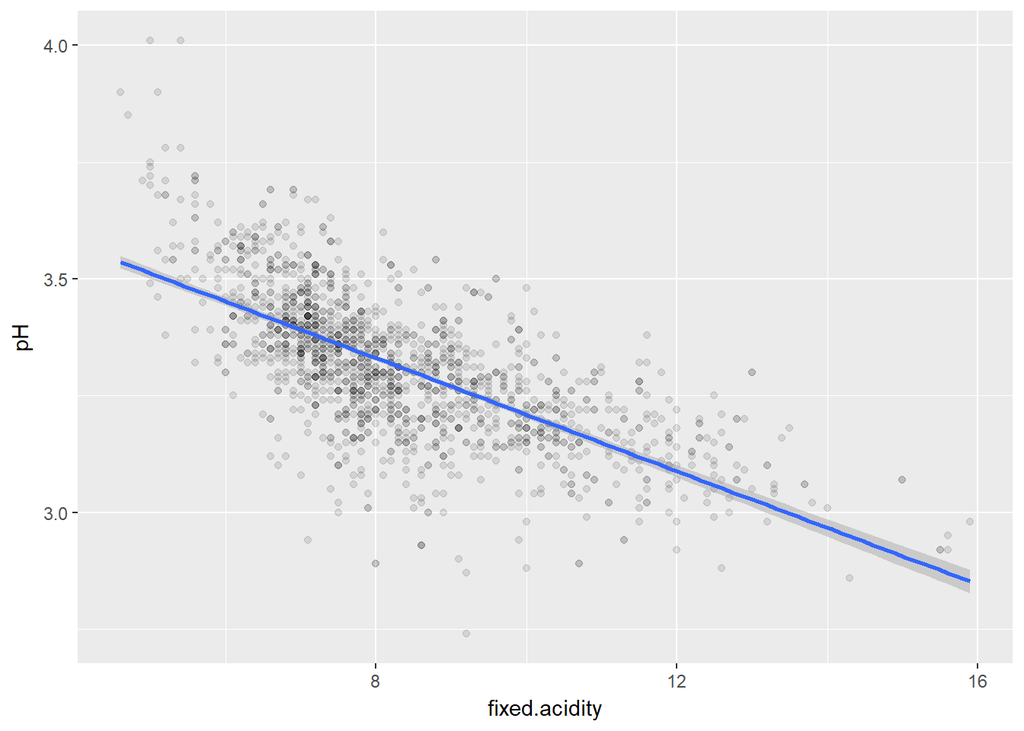

This plot shows a negative correlation which is as expected as lower the pH value, higher is the acidity. The values are clustered between 3.25 and 3.5 pH values. The corresponding fixed acidity values are between 6 and 8.

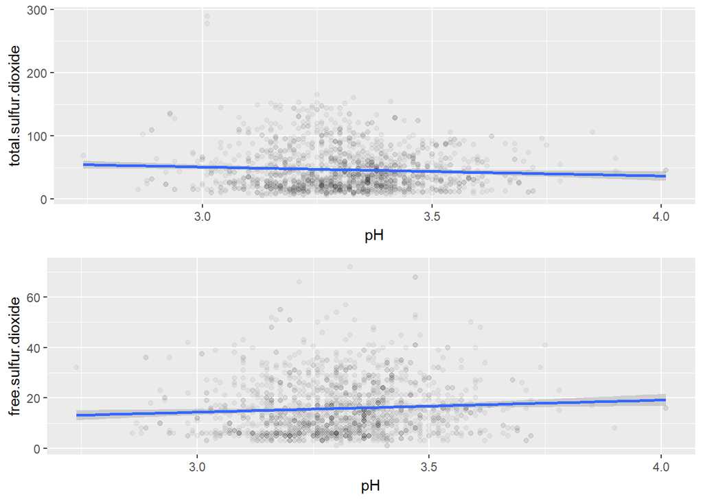

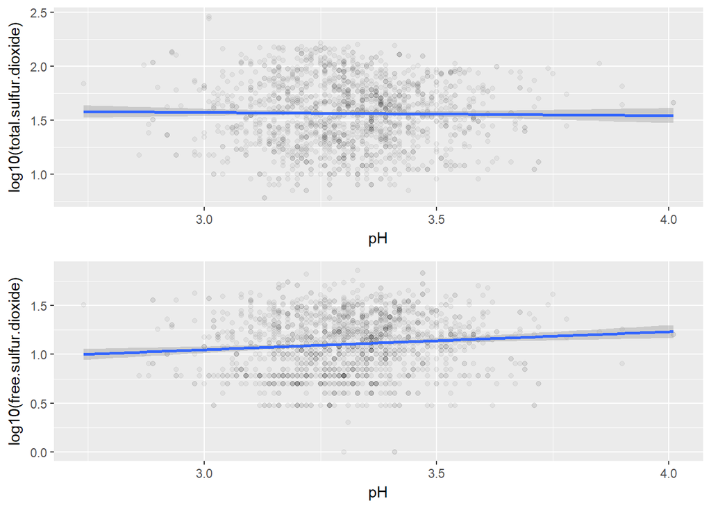

We do not see that trend after transformation. The data values for a certain pH level show high and low sulfur dioxide values. We see very few data clusteres after adding the alpha value even several data points do appear to be close to eachother.

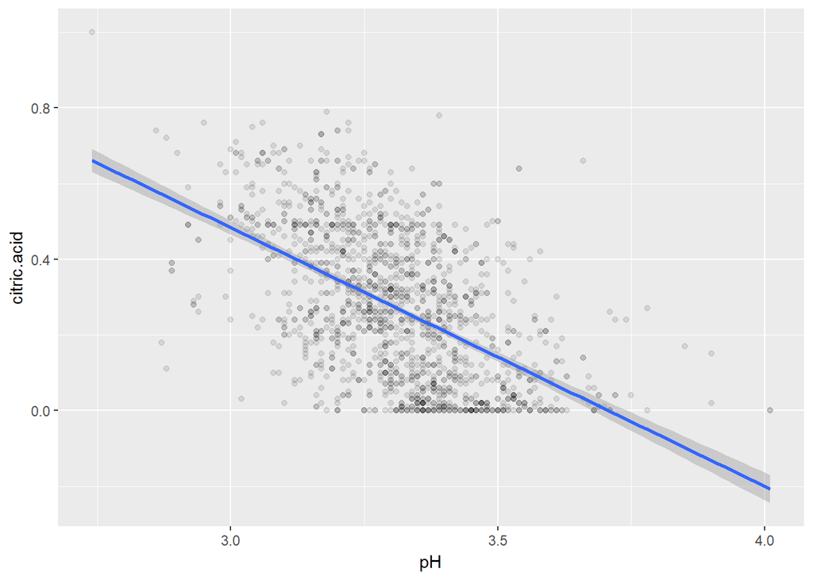

The plot is as expected as higher acidity will result in lower pH values. We can see that there are few clusters of data in different regions of the plot. The most evident being at the citric acid value of 0.

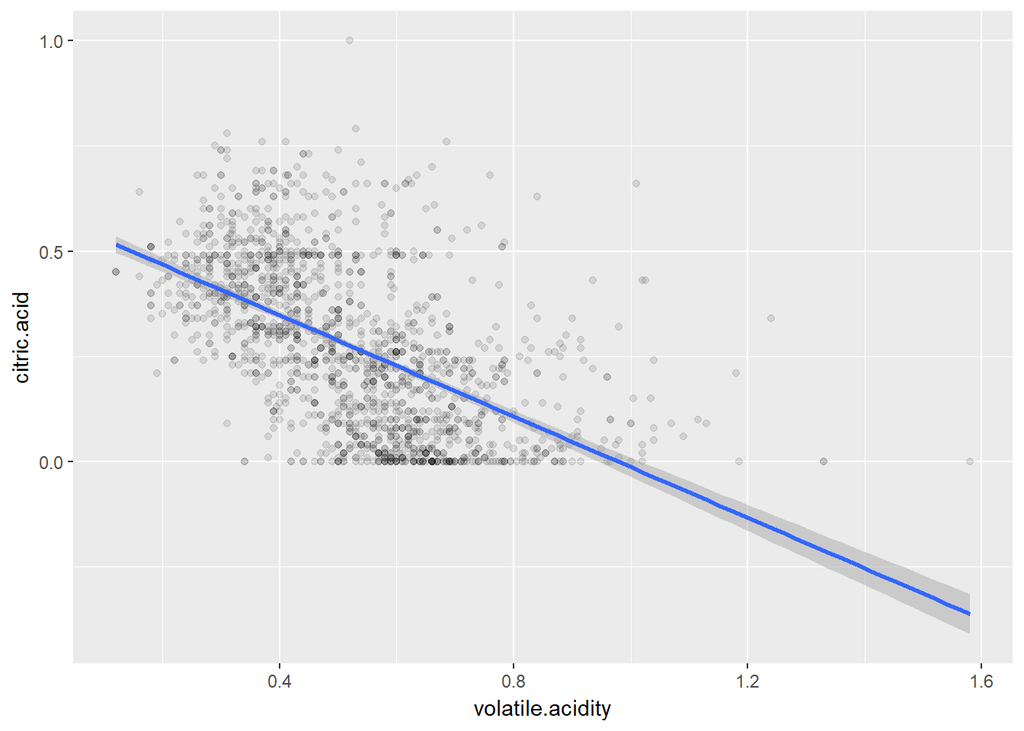

The citric acid content is expected to increase volatile acidity. But that is not the case here as seen from the plot as we see a negative correlation between the variables. We can see small clusters of data values in different regions of the plot.

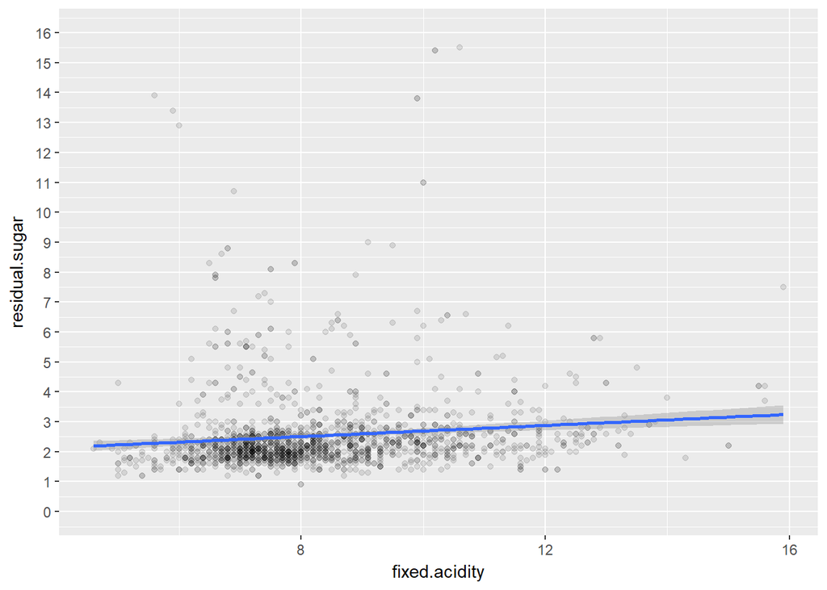

I expected residual sugar and fixed acidity to have a negative correlation as residual sugar is the amount of sugar content in the wine and fixed acidity is the acid content in wine. Let is look at the plot after transforming residual sugar.

We see from the plot above the data is clustered between 1 and 2 values of residual suagr. We almost see a straight line where fixed acidity takes different values.

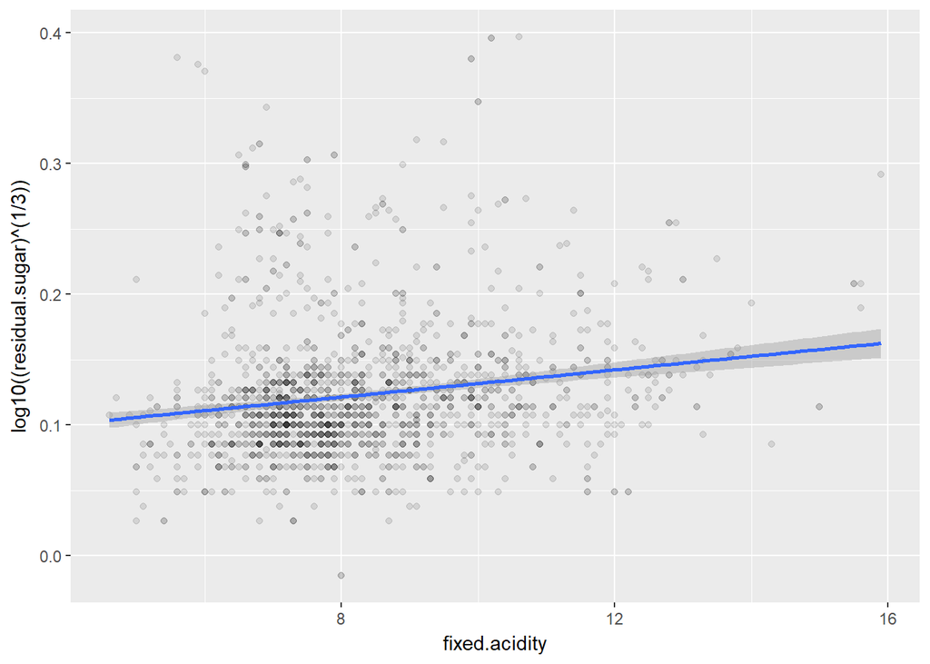

The plot has data that is better dispered than the previous plot. But we still do not see a negative correlation between fixed acidity and residual sugar, which is unsual.

we see tiny clusters of data in different plot regions but it does not provide us with much information.

```
##
##  Pearson's product-moment correlation
##
## data:  red_wine_q$fixed.acidity and log10((red_wine_q$residual.sugar)^(1/3))
## t = 7.0922, df = 1597, p-value = 1.975e-12
## alternative hypothesis: true correlation is not equal to 0
## 95 percent confidence interval:
##  0.1268067 0.2218623
## sample estimates:
##       cor
## 0.1747416
```

The correlation value also indicates that there is very little correlation

# Bivariate Analysis

### Talk about some of the relationships you observed in this part of the investigation. How did the feature(s) of interest vary with other features in the dataset?

The Boxplot between quality and other variables was very eye-opening. The fact that alcohol, fixed acidity, sulphates and citric acid have a positive relationship has helped us understand how relationship of other variables with these variables might affect the quality of wine.

### Did you observe any interesting relationships between the other features (not the main feature(s) of interest)?

The relationship between density with fixed acidity and density with pH is interesting. As we know that fixed acidity and pH are negatively correlated. We understand that density and fixed acidity should have a positive correlation. The interelationship between the three variables can be well understood by the plots shown above.

### What was the strongest relationship you found?

Citric acid and fixed acidity have the highest positive correlation. This is because, the increase in citric acid content increases the fixed acidity value. The correlation value is 0.672 which is the highest correlation value in this plot.

# Multivariate Plots Section

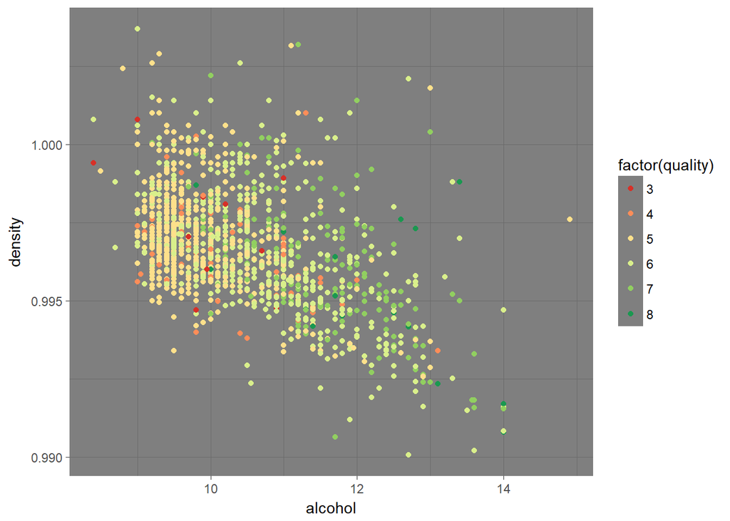

We know from earlier plots that alcohol and quality are positively correlated to each other. We can also notice that most points in the plot have quality values of 5,6 and 7. We can see that higher density values and low alcohol values have a quality level of 5 and 6. For quality levels of 7 and 8 we see lower density values and higher alcohol content values. The density of wine depends on concentration of alcohol, sugar and other dissolved content.

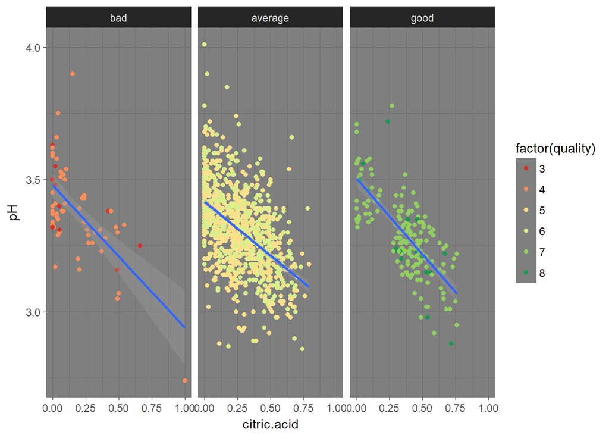

We can see from this relationship that average and good quality wine have nearly the same pH values. We can also see a negative relationship where the citric acid content increases as the pH decreases.

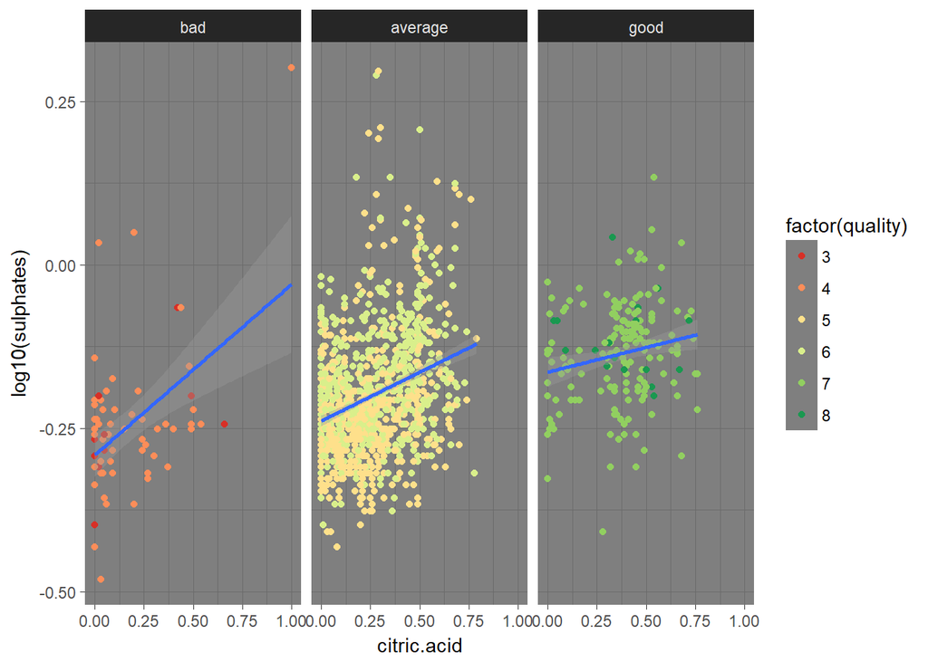

we can see the variation of citric acid with sulphates above. Based on the quality levels, the sulphate values almost tend to increase with citric acid values.

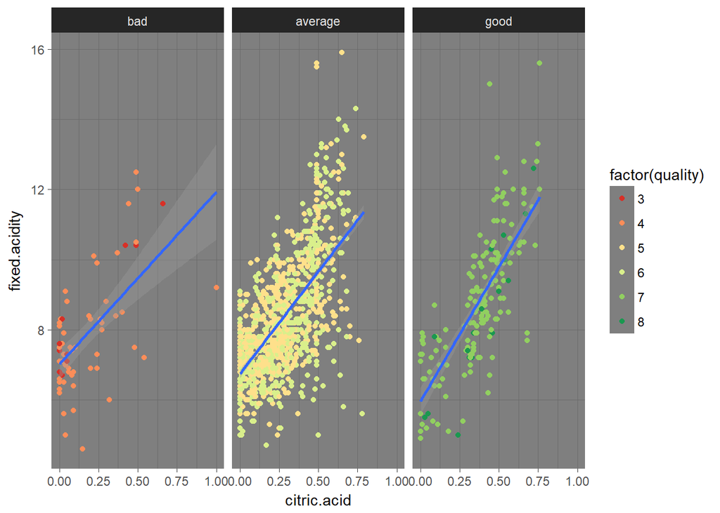

we can see the variation of citric acid with fixed acidity. The fixed acidity values tend to increase with the citric acid values. The dispersion of values based on quality is nearly the same citric acid range on every level.

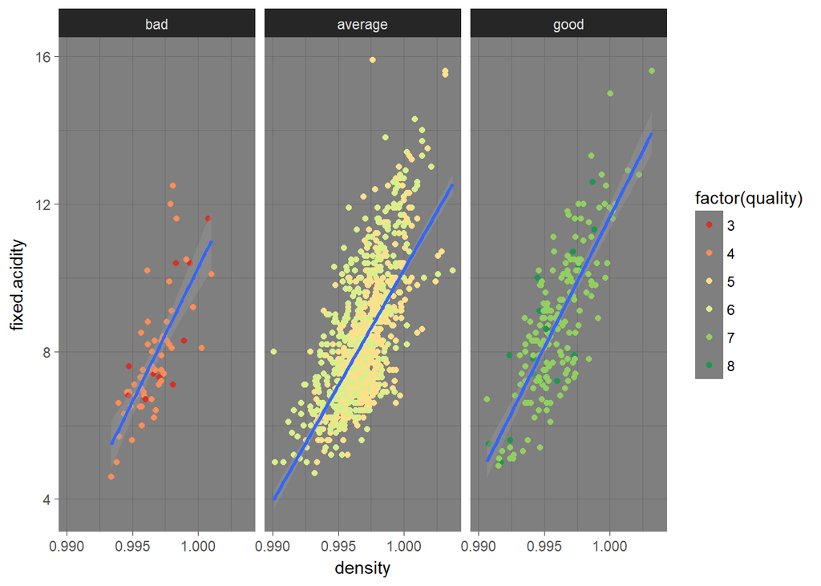

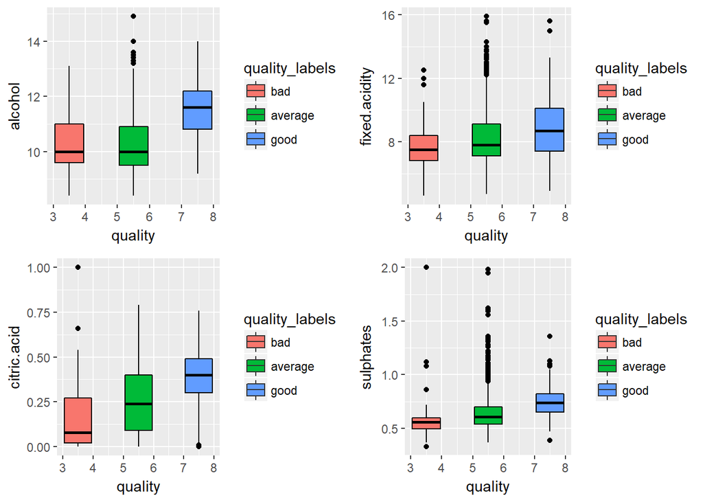

We can see from th boxplots above that wines with high quality values have the following characteristics

1.High alcohol content 2 High fixed acidity 3.High citric acid 4.High sulphate content.

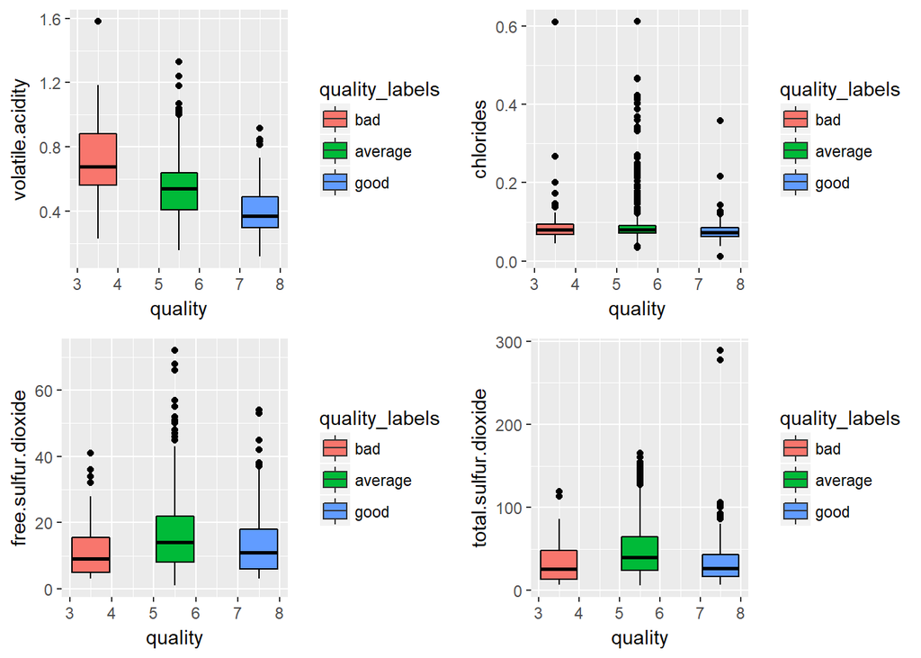

We can see from the boxplots above that wines with high quality values have the following characteristics. The correlation values of quality with these variables are low but the box plots indicates a trend that we use for an assumption. This trend will need to be further investigated

1.low chlorides 2 low volatile acidity 3.medium free sulfur dioxide 4.medium total sulfurd dioxide

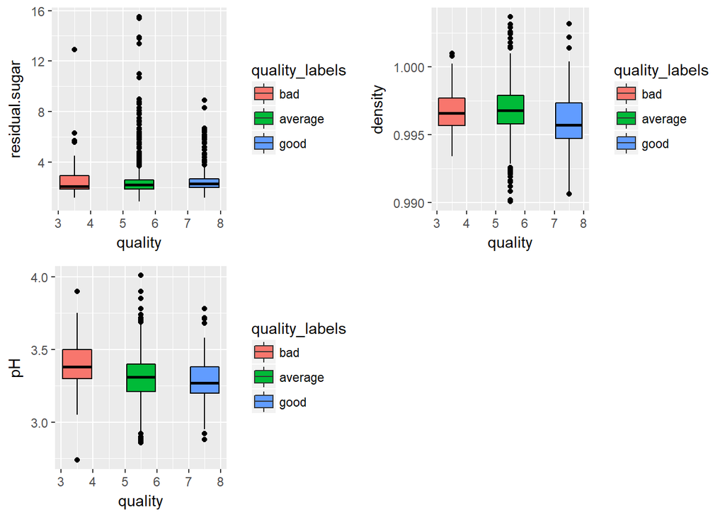

We can see from the boxplots above that wines with high quality values have the following characteristics. The correlation values of quality with these variables are low but the box plots indicates a trend that we use for an assumption. This trend will need to be further investigated

1.low density 2 low pH 3.medium residual sugar

# Multivariate Analysis

### Talk about some of the relationships you observed in this part of the investigation. Were there features that strengthened each other in terms of looking at your feature(s) of interest?

FROM SCATTER PLOTS:

We examined the relationship between variables that have a high correlation with quality. By dividing the quality values into 3 different sections, we observed if the relationship between these variables change between quality levels. In most cases the relationship remained consistent between quality levels.

we examined the range of the values with respect to quality levels. X range and y range of values in different quality levels almost remained the same.

FROM BOXPLOTS The boxplots provided a better understanding of how the variables change with quality levels. The first four variables have a high correlation with quality. The remaining variables have poor correlation with quality but these values can be assumed for these variables.

1.High alcohol content 2 High fixed acidity 3.High citric acid 4.High sulphate content. 5.low chlorides 6 low volatile acidity 7.medium free sulfur dioxide 8.medium total sulfurd dioxide 9.low density 10 low pH 11.medium residual sugar

### Were there any interesting or surprising interactions between features?

# Final Plots and Summary

### Plot One

[figure not shown]

This plot I believe is the best plot generated as it shows how the variables with high correlation values with quality vary across quality levels. The high correlation values justify our intepretation of the results that goof quality wine will have the following characterstics.

1.High alcohol content 2 High fixed acidity 3.High citric acid 4.High sulphate content.

### Plot Two

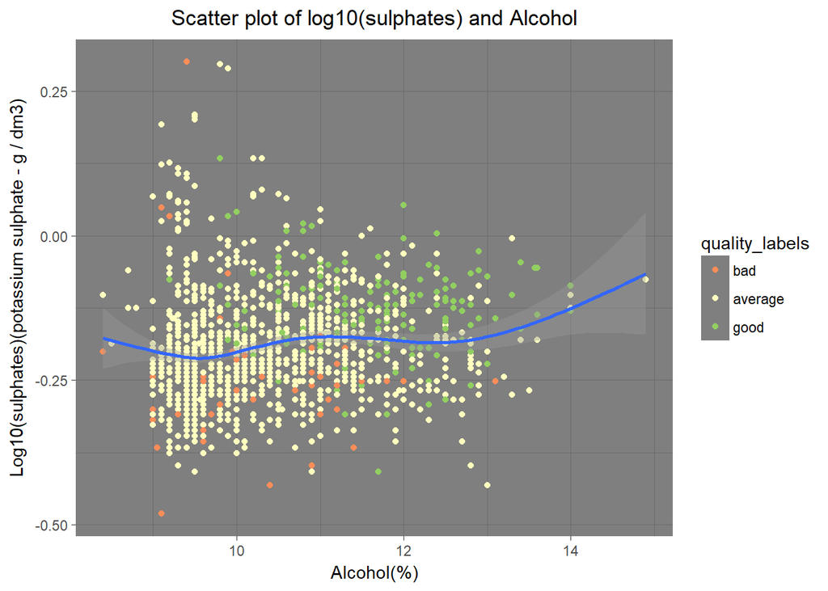

Our boxplot model above showed us best quality wine will have high alcohol and high sulphate content. This plot shows that most values with a wine rating of good have high alcohol and sulphur content. A few values with high alcohol and sulphate content are also shown to have average rating, this is likely because one of the other variables do not match with our good wine rating variable assumptions.

### Plot Three

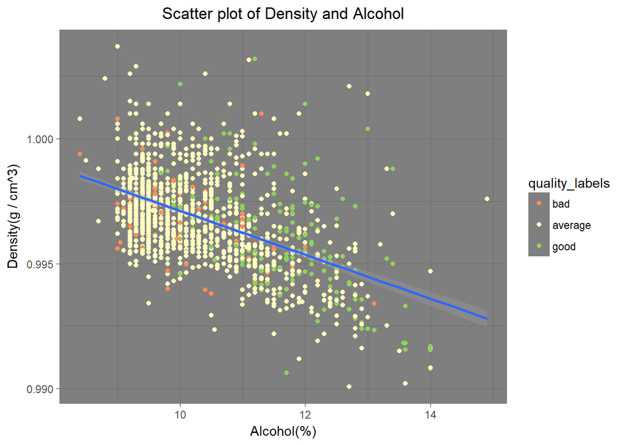

This relationship is interesting as the density values tend to decrease with alcohol content.This is unexpected. Higher density should mean higher alcohol content as density of wine is made of concentration of alcohol, sugar and disolved content.

We know that alcohol and quality are postively correlated. We can actually see that higher alcohol values have quality label to be good. Also our assumption from the boxplot is that good quality wines have low density. We can actually see that density values decrease as the wine quality improves. A few data points with low density and high alcohol content are still given an average wine quality rating. This may be due to other variables not following the standards for good wine quality. These standards are described at the end of plot 1.

# Reflection

This exploratory analysis helped identify factors that influence wine ratings. The analysis provided with sound correlations for few variables and certain assumptions were made on other variables based on the plots. Sufficient evidence is provided on most variables with plots showing bad, average and good wine ratings. This analysis will prove useful in predicting the success or failure of a wine based on its chemical compositions. Wine quality varies with people so there might be cases where quality ratings are different from our assumptions. Further study with a large dataset where the wine is from a single source or the same group of people are sampled may provide more informative results.